# **Notas 4**

Ana Sofia Escobedo Muñoz

27/02/21

# Revision y spatialLIBD

## Revision de temas vistos

- ¿Debemos explorar las relaciones entre nuestras variables con información de nuestras muestras previo a hacer un análisis de expresión diferencial?

Si, es uno de los pasos mas importantes para establecer un modelo estadistico que será la base del analisis de ED

- ¿Por qué usamos el paquete edgeR?

Para normalizar los datos, eliminando el composition bias.

- ¿Por qué es importante el argumento sort.by en topTable()?

Indicar el orden de la salida de genes (si sort.by= ‘none’, se mantiene el orden original)

- ¿Por qué es importante el argumento coef en topTable()?

Indica cual elemento del modelo será considerado mas en cuenta para la ED

### Ejercicio en grupos

```r
speaqeasy_data <- file.path(tempdir(), "rse_speaqeasy.RData")
download.file("https://github.com/LieberInstitute/SPEAQeasy-example/blob/master/rse_speaqeasy.RData?raw=true", speaqeasy_data, mode = "wb")
suppressPackageStartupMessages(library("SummarizedExperiment"))
load(speaqeasy_data, verbose = TRUE)
```

```
Loading objects:
  rse_gene
```

```r
rse_gene
```

```
class: RangedSummarizedExperiment
dim: 60609 40
metadata(0):
assays(1): counts
rownames(60609): ENSG00000223972.5 ENSG00000227232.5 ...
  ENSG00000210195.2 ENSG00000210196.2
rowData names(10): Length gencodeID ... NumTx gencodeTx
colnames(40): R13896_H7JKMBBXX R13903_HCTYLBBXX ... R15120_HFY2MBBXX
  R15134_HFFGHBBXX
colData names(67): SAMPLE_ID FQCbasicStats ... AgeDeath BrNum
```

- ¿Hay diferencias en totalAssignedGene o mitoRate entre los grupos de diagnosis (PrimaryDx)?

```r
cosito <- data.frame(rse_gene$totalAssignedGene, rse_gene$mitoRate, rse_gene$PrimaryDx)
control <- cosito[cosito$rse_gene.PrimaryDx == "Control", ]
bipolar <- cosito[cosito$rse_gene.PrimaryDx == "Bipolar",]
summary(control$rse_gene.totalAssignedGene)
```

```
   Min. 1st Qu.  Median    Mean 3rd Qu.    Max.
 0.1384  0.2575  0.2895  0.2984  0.3537  0.4073
```

```r
summary(bipolar$rse_gene.totalAssignedGene)
```

```
   Min. 1st Qu.  Median    Mean 3rd Qu.    Max.
0.09529 0.24454 0.29773 0.28867 0.34662 0.38358
```

```r
summary(control$rse_gene.totalAssignedGene)
```

```
   Min. 1st Qu.  Median    Mean 3rd Qu.    Max.
 0.1384  0.2575  0.2895  0.2984  0.3537  0.4073
```

```r
summary(bipolar$rse_gene.totalAssignedGene)
```

```
   Min. 1st Qu.  Median    Mean 3rd Qu.    Max.
0.09529 0.24454 0.29773 0.28867 0.34662 0.38358
```

- Grafica la expresión de SNAP25 para cada grupo de diagnosis.

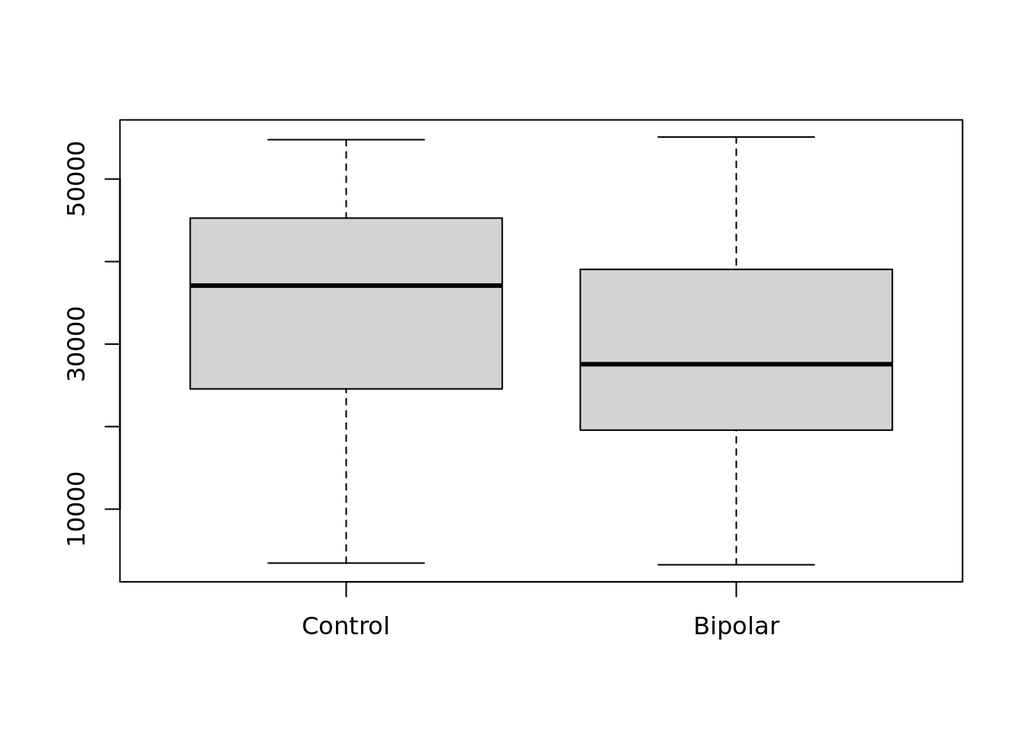

```r
genePos <- match('SNAP25',rowRanges(rse_gene)$Symbol)
cuentas <- as.vector(assay(rse_gene[genePos,], "counts"))
cositoCuen <- cbind(cosito, cuentas)
bipolarCuen <- cositoCuen[cositoCuen$rse_gene.PrimaryDx == "Bipolar",]
controlCuen <- cositoCuen[cositoCuen$rse_gene.PrimaryDx == "Control", ]

boxplot(x = cbind(controlCuen$cuentas,bipolarCuen$cuentas), names= c('Control', 'Bipolar'))
```

- Sugiere un modelo estadistico que podríamos usar en una análisis de expresión diferencial. Verifica que si sea un modelo full rank. ¿Cúal sería el o los coeficientes de interés?

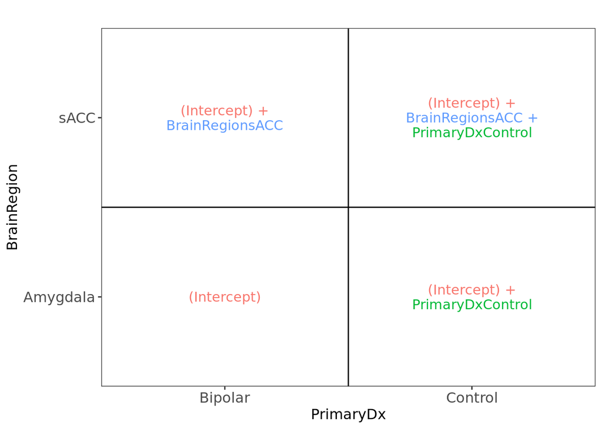

```r
dfCdmx <- as.data.frame(cbind(as.vector(rse_gene$BrainRegion),as.vector(rse_gene$PrimaryDx)))

names(dfCdmx) <- c('BrainRegion','PrimaryDx')

vd <- ExploreModelMatrix::VisualizeDesign(
    sampleData = dfCdmx,
    designFormula = ~ BrainRegion + PrimaryDx,
    textSizeFitted = 4
)

cowplot::plot_grid(plotlist = vd$plotlist)
```